# Cultural heritage caring scale validation walkthrough

Alessandro von Gal

2024-12-17

Here are the step-by-step analyses for the validation of the Cultural Heritage Caring scale using the Rasch appraoch.

## **1. Fitting the Rasch Model**

### **Dichotomization of responses**

```r
library(readxl)
data <- read_xlsx('chare_clean.xlsx')

items<- subset(data[c(5:20)])
#recodes responses into dichotomical values
library(dplyr)
items <- items %>%
  mutate(across(1:16, ~ recode(.x, `1` = 0, `2` = 0, `3` = 0, `4` = 1, `5` = 1, `6` = 1)))
```

Dichotomized items table:

Dichotmoized items

| A1 | A2 | A3 | B1 | B2 | B3 | C1 | C2 | C3 | D1 | D2 | D3 | E1 | E2 | E3 | E4 |
| --- | --- | --- | --- | --- | --- | --- | --- | --- | --- | --- | --- | --- | --- | --- | --- |
| 0 | 0 | 0 | 0 | 0 | 0 | 0 | 0 | 0 | 0 | 0 | 0 | 0 | 0 | 0 | 0 |
| 1 | 0 | 0 | 0 | 1 | 0 | 0 | 0 | 0 | 0 | 0 | 0 | 0 | 0 | 0 | 0 |
| 1 | 1 | 0 | 1 | 1 | 0 | 0 | 1 | 0 | 1 | 1 | 0 | 0 | 0 | 0 | 0 |
| 1 | 0 | 0 | 0 | 0 | 0 | 1 | 0 | 0 | 1 | 1 | 0 | 0 | 0 | 0 | 0 |
| 1 | 1 | 1 | 0 | 0 | 1 | 0 | 0 | 0 | 1 | 0 | 1 | 0 | 0 | 0 | 0 |
| 0 | 0 | 0 | 0 | 0 | 0 | 0 | 0 | 0 | 0 | 0 | 0 | 0 | 0 | 0 | 0 |
| 1 | 1 | 1 | 0 | 0 | 1 | 1 | 1 | 0 | 1 | 1 | 0 | 0 | 0 | 0 | 0 |
| 1 | 1 | 1 | 1 | 1 | 1 | 1 | 1 | 0 | 1 | 1 | 1 | 0 | 0 | 0 | 0 |
| 0 | 0 | 1 | 0 | 1 | 1 | 1 | 1 | 1 | 1 | 0 | 0 | 0 | 0 | 0 | 0 |
| 1 | 1 | 0 | 1 | 1 | 1 | 0 | 0 | 0 | 1 | 0 | 1 | 0 | 0 | 0 | 0 |
| 1 | 1 | 0 | 1 | 1 | 1 | 1 | 1 | 0 | 1 | 1 | 1 | 1 | 1 | 0 | 0 |
| 1 | 0 | 0 | 0 | 1 | 1 | 1 | 1 | 0 | 0 | 0 | 0 | 0 | 0 | 0 | 0 |
| 1 | 1 | 1 | 1 | 1 | 1 | 1 | 0 | 0 | 0 | 0 | 1 | 1 | 1 | 0 | 0 |
| 1 | 0 | 1 | 0 | 1 | 0 | 0 | 0 | 1 | 1 | 0 | 1 | 0 | 0 | 0 | 0 |
| 1 | 1 | 1 | 0 | 0 | 0 | 1 | 1 | 0 | 1 | 1 | 1 | 0 | 0 | 0 | 0 |
| 1 | 1 | 0 | 1 | 1 | 0 | 1 | 0 | 0 | 1 | 1 | 1 | 0 | 0 | 0 | 0 |
| 1 | 0 | 0 | 1 | 1 | 1 | 1 | 1 | 0 | 1 | 0 | 1 | 0 | 0 | 0 | 0 |
| 0 | 0 | 0 | 0 | 0 | 1 | 1 | 1 | 0 | 0 | 0 | 1 | 0 | 0 | 0 | 0 |
| 0 | 0 | 0 | 1 | 1 | 1 | 0 | 0 | 0 | 0 | 0 | 0 | 0 | 0 | 0 | 0 |
| 0 | 1 | 1 | 0 | 0 | 0 | 1 | 1 | 0 | 0 | 0 | 0 | 0 | 0 | 0 | 0 |
| 1 | 0 | 0 | 1 | 1 | 0 | 0 | 1 | 0 | 1 | 1 | 1 | 0 | 0 | 0 | 0 |
| 1 | 1 | 1 | 1 | 1 | 1 | 1 | 1 | 0 | 1 | 1 | 1 | 0 | 0 | 0 | 1 |
| 0 | 0 | 0 | 0 | 0 | 0 | 0 | 1 | 0 | 0 | 0 | 0 | 0 | 0 | 0 | 0 |
| 1 | 0 | 0 | 1 | 1 | 0 | 0 | 1 | 0 | 0 | 0 | 0 | 0 | 0 | 0 | 0 |
| 1 | 1 | 1 | 1 | 0 | 1 | 1 | 1 | 0 | 1 | 1 | 1 | 0 | 0 | 0 | 0 |
| 0 | 0 | 0 | 0 | 0 | 0 | 0 | 1 | 1 | 0 | 0 | 1 | 0 | 0 | 0 | 0 |
| 0 | 0 | 0 | 0 | 0 | 0 | 0 | 0 | 0 | 0 | 0 | 0 | 0 | 0 | 0 | 0 |
| 0 | 0 | 0 | 1 | 1 | 0 | 1 | 1 | 0 | 1 | 0 | 0 | 0 | 0 | 0 | 0 |
| 0 | 0 | 0 | 0 | 0 | 0 | 0 | 1 | 0 | 1 | 0 | 0 | 0 | 0 | 0 | 0 |
| 0 | 0 | 0 | 0 | 0 | 0 | 1 | 1 | 0 | 1 | 1 | 1 | 0 | 0 | 0 | 0 |
| 1 | 0 | 0 | 0 | 0 | 1 | 0 | 0 | 0 | 0 | 0 | 0 | 0 | 0 | 0 | 0 |
| 1 | 1 | 1 | 0 | 1 | 1 | 1 | 1 | 0 | 1 | 1 | 1 | 0 | 0 | 0 | 0 |
| 0 | 0 | 0 | 0 | 0 | 0 | 0 | 1 | 0 | 1 | 0 | 0 | 0 | 0 | 0 | 0 |
| 1 | 1 | 1 | 1 | 1 | 1 | 1 | 1 | 0 | 1 | 1 | 1 | 0 | 0 | 0 | 0 |
| 1 | 0 | 1 | 1 | 1 | 1 | 1 | 1 | 0 | 1 | 1 | 1 | 0 | 1 | 0 | 0 |
| 0 | 0 | 0 | 0 | 0 | 1 | 0 | 0 | 0 | 0 | 0 | 0 | 0 | 0 | 0 | 0 |
| 1 | 0 | 0 | 0 | 0 | 0 | 0 | 1 | 0 | 0 | 0 | 0 | 0 | 0 | 0 | 0 |
| 1 | 0 | 0 | 1 | 0 | 1 | 1 | 0 | 0 | 1 | 0 | 0 | 0 | 0 | 0 | 0 |
| 0 | 0 | 0 | 0 | 0 | 0 | 1 | 0 | 0 | 0 | 0 | 0 | 0 | 0 | 0 | 0 |
| 0 | 0 | 0 | 1 | 1 | 1 | 0 | 1 | 0 | 1 | 0 | 1 | 0 | 0 | 0 | 0 |
| 1 | 1 | 1 | 1 | 1 | 1 | 1 | 1 | 0 | 1 | 1 | 1 | 0 | 0 | 0 | 0 |
| 1 | 0 | 0 | 1 | 1 | 1 | 1 | 1 | 0 | 1 | 1 | 1 | 0 | 0 | 0 | 0 |
| 0 | 0 | 0 | 1 | 1 | 0 | 0 | 1 | 1 | 0 | 0 | 0 | 0 | 0 | 0 | 0 |
| 0 | 0 | 0 | 0 | 0 | 0 | 1 | 1 | 1 | 0 | 0 | 1 | 0 | 0 | 0 | 0 |
| 1 | 0 | 0 | 1 | 1 | 0 | 0 | 0 | 0 | 1 | 1 | 0 | 0 | 0 | 0 | 0 |
| 1 | 0 | 0 | 0 | 0 | 0 | 1 | 0 | 0 | 0 | 1 | 1 | 0 | 0 | 0 | 0 |
| 0 | 1 | 1 | 1 | 1 | 0 | 0 | 1 | 0 | 0 | 1 | 1 | 0 | 0 | 0 | 0 |
| 0 | 0 | 0 | 1 | 1 | 1 | 0 | 1 | 1 | 1 | 1 | 1 | 0 | 0 | 0 | 0 |
| 1 | 1 | 1 | 0 | 0 | 1 | 1 | 1 | 0 | 1 | 1 | 1 | 0 | 0 | 0 | 0 |
| 1 | 1 | 0 | 1 | 1 | 1 | 0 | 1 | 0 | 1 | 1 | 1 | 0 | 0 | 0 | 0 |
| 1 | 1 | 1 | 1 | 1 | 1 | 1 | 1 | 1 | 1 | 1 | 1 | 1 | 0 | 0 | 0 |
| 1 | 0 | 1 | 1 | 1 | 1 | 1 | 1 | 0 | 1 | 1 | 1 | 0 | 0 | 0 | 0 |

Item 15 (E3) presents all 0 responses, meaning that it is not a good estimator of the behavior. Indeed, it would be interpreted as too difficult given that no one reports to engage in this specific behavior. As such, we exclude it from the estimation (the RM function would exclude it automatically). N.B. Although unlikely, a larger sample size may include participants who engage in this behavior, justifying the retention of the item.

### **Rasch model and person parameter estimation**

```r
#we exclude item 15 prior to estimating the model
items <- subset(items, select = - E3)
#Rasch model and person parameter estimation
library(eRm)
RaschModel <- RM(items)
pp <- person.parameter(RaschModel)
```

We can now check the itemfit statistics of our set of items using `itemfit(pp)`

```r
ifit<- itemfit(pp)
print(ifit)
```

```
##
## Itemfit Statistics:
##      Chisq df p-value Outfit MSQ Infit MSQ Outfit t Infit t Discrim
## A1  39.095 48   0.817      0.798     0.993   -0.439   0.013   0.481
## A2  34.582 48   0.927      0.706     0.851   -0.953  -0.859   0.638
## A3  39.103 48   0.816      0.798     0.879   -0.561  -0.663   0.606
## B1  40.856 48   0.758      0.834     0.969   -0.496  -0.150   0.564
## B2  46.002 48   0.555      0.939     1.006   -0.080   0.088   0.518
## B3  48.126 48   0.468      0.982     0.992    0.043  -0.001   0.504
## C1  49.367 48   0.418      1.007     1.101    0.129   0.678   0.442
## C2  61.095 48   0.097      1.247     1.249    0.651   1.383   0.254
## C3 139.747 48   0.000      2.852     1.558    1.931   1.879  -0.041
## D1  38.668 48   0.830      0.789     0.826   -0.466  -1.093   0.535
## D2  32.185 48   0.961      0.657     0.788   -1.271  -1.393   0.640
## D3  30.010 48   0.980      0.612     0.781   -1.263  -1.463   0.629
## E1  12.432 48   1.000      0.254     0.638   -0.404  -0.881   0.467
## E2  16.386 48   1.000      0.334     0.895   -0.264  -0.130   0.397
## E4   7.283 48   1.000      0.149     0.726    0.215  -0.163   0.205
```

Based on [Linacre guidelines on response scales](https://www.rasch.org/rmt/rmt83b.htm) for which acceptable values range from 0.6 to 1.4, item C3 appears to potentially distort the Rasch measurement.

#### **Point biserial correlation of the 15 item version**

At this point we calculate point-biserial correlation for each item to test for item discrimination (compared to the other items in the scale). A significant low correlation indicates that the test item shows different discrimination compared to the other items.

```r
#creates matrix by excluding person zero and person perfect individuals
rmat <- as.matrix(items[-pp[["pers.ex"]],])

calculate_point_biserial <- function(rmat) {
  n_items <- ncol(rmat)
  results <- list()

  for (i in 1:n_items) {
    idxt <- i
    idxs <- setdiff(1:n_items, idxt)

    tpbis <- NPtest(rmat, method = "Tpbis", idxt = idxt, idxs = idxs,seed=123)
    results[[paste("Item", i)]] <- tpbis
  }

  return(results)
}
# Perform the point-biserial correlation test for each item
tpbis_results <- calculate_point_biserial(rmat)
# Print the results for each item
for (item in names(tpbis_results)) {
  cat("\nResults for", item, ":\n")
  print(tpbis_results[[item]])
}
```

```
##
## Results for Item 1 :
## Nonparametric RM model test: Tpbis (discrimination)
##     (pointbiserial correlation of test item vs. subscale)
## Number of sampled matrices: 500
## Test Item: 1
## Subscale  - Items: 2 3 4 5 6 7 8 9 10 11 12 13 14 15
## one-sided p-value (rpbis too low): 0.524
##
##
## Results for Item 2 :
## Nonparametric RM model test: Tpbis (discrimination)
##     (pointbiserial correlation of test item vs. subscale)
## Number of sampled matrices: 500
## Test Item: 2
## Subscale  - Items: 1 3 4 5 6 7 8 9 10 11 12 13 14 15
## one-sided p-value (rpbis too low): 0.814
##
##
## Results for Item 3 :
## Nonparametric RM model test: Tpbis (discrimination)
##     (pointbiserial correlation of test item vs. subscale)
## Number of sampled matrices: 500
## Test Item: 3
## Subscale  - Items: 1 2 4 5 6 7 8 9 10 11 12 13 14 15
## one-sided p-value (rpbis too low): 0.74
##
##
## Results for Item 4 :
## Nonparametric RM model test: Tpbis (discrimination)
##     (pointbiserial correlation of test item vs. subscale)
## Number of sampled matrices: 500
## Test Item: 4
## Subscale  - Items: 1 2 3 5 6 7 8 9 10 11 12 13 14 15
## one-sided p-value (rpbis too low): 0.516
##
##
## Results for Item 5 :
## Nonparametric RM model test: Tpbis (discrimination)
##     (pointbiserial correlation of test item vs. subscale)
```

[output cut: 79 more lines]

```
## Nonparametric RM model test: Tpbis (discrimination)
##     (pointbiserial correlation of test item vs. subscale)
## Number of sampled matrices: 500
## Test Item: 14
## Subscale  - Items: 1 2 3 4 5 6 7 8 9 10 11 12 13 15
## one-sided p-value (rpbis too low): 0.656
##
##
## Results for Item 15 :
## Nonparametric RM model test: Tpbis (discrimination)
##     (pointbiserial correlation of test item vs. subscale)
## Number of sampled matrices: 500
## Test Item: 15
## Subscale  - Items: 1 2 3 4 5 6 7 8 9 10 11 12 13 14
## one-sided p-value (rpbis too low): 0.768
```

We observe that item C3 is the only one showing significant point-biserial correlation, indicating low discrimination.

Based on this and the high MSQ values, we re-fit the model by only excluding this item, while keeping the items that have values lower than 0.6, for now.

```r
items<- subset(data[c(5:20)])
#recodes responses into dichotomical values
library(dplyr)
items <- items %>%
  mutate(across(1:16, ~ recode(.x, `1` = 0, `2` = 0, `3` = 0, `4` = 1, `5` = 1, `6` = 1)))
#we exclude items 9 and 15 prior to estimating the model
items <- subset(items, select = - c(E3,C3))
#Rasch model and person parameter estimation
library(eRm)
RaschModel <- RM(items)
pp <- person.parameter(RaschModel)
```

We now see the Itemfit statistics excluding item C3. Having excluded the uncooperative item we should see that other items recentralize. However, some items still present low mean-square values.

```r
ifit<- itemfit(pp)
print(ifit)
```

```
##
## Itemfit Statistics:
##     Chisq df p-value Outfit MSQ Infit MSQ Outfit t Infit t Discrim
## A1 36.123 48   0.896      0.737     0.972   -0.433  -0.118   0.518
## A2 36.750 48   0.882      0.750     0.890   -0.665  -0.546   0.656
## A3 51.226 48   0.348      1.045     0.964    0.244  -0.123   0.589
## B1 43.289 48   0.666      0.883     1.013   -0.214   0.136   0.572
## B2 50.734 48   0.366      1.035     1.079    0.222   0.532   0.497
## B3 47.782 48   0.482      0.975     1.027    0.059   0.221   0.514
## C1 49.515 48   0.413      1.011     1.141    0.158   0.889   0.454
## C2 68.962 48   0.025      1.407     1.324    0.813   1.758   0.234
## D1 41.979 48   0.717      0.857     0.835   -0.147  -1.016   0.541
## D2 32.281 48   0.960      0.659     0.804   -1.021  -1.194   0.660
## D3 32.048 48   0.963      0.654     0.838   -0.820  -1.012   0.604
## E1 12.642 48   1.000      0.258     0.700   -0.165  -0.743   0.431
## E2 15.227 48   1.000      0.311     0.883   -0.088  -0.187   0.400
## E4  4.758 48   1.000      0.097     0.589    0.384  -0.491   0.212
```

Items E1, E2, and E4 overfit (<0.6), this means that these items are less productive for measurement although not degrading. They may produce inflated good reliabilities.

#### **Point biserial correlation of the 14 item version**

We re-check for point-biserial correlation.

```r
#creates matrix by excluding person zero and person perfect individuals
rmat <- as.matrix(items[-pp[["pers.ex"]],])

calculate_point_biserial <- function(rmat) {
  n_items <- ncol(rmat)
  results <- list()

  for (i in 1:n_items) {
    idxt <- i
    idxs <- setdiff(1:n_items, idxt)

    tpbis <- NPtest(rmat, method = "Tpbis", idxt = idxt, idxs = idxs,seed=123)
    results[[paste("Item", i)]] <- tpbis
  }

  return(results)
}
# Perform the point-biserial correlation test for each item
tpbis_results <- calculate_point_biserial(rmat)
# Print the results for each item
for (item in names(tpbis_results)) {
  cat("\nResults for", item, ":\n")
  print(tpbis_results[[item]])
}
```

```
##
## Results for Item 1 :
## Nonparametric RM model test: Tpbis (discrimination)
##     (pointbiserial correlation of test item vs. subscale)
## Number of sampled matrices: 500
## Test Item: 1
## Subscale  - Items: 2 3 4 5 6 7 8 9 10 11 12 13 14
## one-sided p-value (rpbis too low): 0.538
##
##
## Results for Item 2 :
## Nonparametric RM model test: Tpbis (discrimination)
##     (pointbiserial correlation of test item vs. subscale)
## Number of sampled matrices: 500
## Test Item: 2
## Subscale  - Items: 1 3 4 5 6 7 8 9 10 11 12 13 14
## one-sided p-value (rpbis too low): 0.738
##
##
## Results for Item 3 :
## Nonparametric RM model test: Tpbis (discrimination)
##     (pointbiserial correlation of test item vs. subscale)
## Number of sampled matrices: 500
## Test Item: 3
## Subscale  - Items: 1 2 4 5 6 7 8 9 10 11 12 13 14
## one-sided p-value (rpbis too low): 0.5
##
##
## Results for Item 4 :
## Nonparametric RM model test: Tpbis (discrimination)
##     (pointbiserial correlation of test item vs. subscale)
## Number of sampled matrices: 500
## Test Item: 4
## Subscale  - Items: 1 2 3 5 6 7 8 9 10 11 12 13 14
## one-sided p-value (rpbis too low): 0.424
##
##
## Results for Item 5 :
## Nonparametric RM model test: Tpbis (discrimination)
##     (pointbiserial correlation of test item vs. subscale)
```

[output cut: 70 more lines]

```
## Nonparametric RM model test: Tpbis (discrimination)
##     (pointbiserial correlation of test item vs. subscale)
## Number of sampled matrices: 500
## Test Item: 13
## Subscale  - Items: 1 2 3 4 5 6 7 8 9 10 11 12 14
## one-sided p-value (rpbis too low): 0.646
##
##
## Results for Item 14 :
## Nonparametric RM model test: Tpbis (discrimination)
##     (pointbiserial correlation of test item vs. subscale)
## Number of sampled matrices: 500
## Test Item: 14
## Subscale  - Items: 1 2 3 4 5 6 7 8 9 10 11 12 13
## one-sided p-value (rpbis too low): 1
```

Point-biserial correlation is good for all items except C2. Given the very low MSQ fit values, **we proceed by excluding the overfitting items and re-fitting the model**

```r
items<- subset(data[c(5:20)])
#recodes responses into dichotomical values
library(dplyr)
items <- items %>%
  mutate(across(1:16, ~ recode(.x, `1` = 0, `2` = 0, `3` = 0, `4` = 1, `5` = 1, `6` = 1)))
#we exclude items 9 and 15 prior to estimating the model
items <- subset(items, select = - c(E3,C3,E1,E2,E4))
#Rasch model and person parameter estimation
library(eRm)
RaschModel <- RM(items)
pp <- person.parameter(RaschModel)
```

[output not shown]

We finally obtained a set of items with satisfying itemfit values. This is confirmed by the infit t-statistics plot where all items are within the -2 and +2 boundaries.

We obtain Item difficulty and Std error to be included in the table:

```r
#the eRm package doesn't have a built in function to calculate this, so we do this by hand.
#First we obtain item difficulties
item_diff<- round(RaschModel$betapar*(-1),3) #betapar is the item easiness; inverting it by *(-1) results in item difficulty.
#Then we need items standard error
item_se <- round(RaschModel$se.beta,3)
```

[figure not shown]

#### **Point biserial correlations for the 11-item model**

```r
#creates matrix by excluding person zero and person perfect individuals
rmat <- as.matrix(items[-pp[["pers.ex"]],])

calculate_point_biserial <- function(rmat) {
  n_items <- ncol(rmat)
  results <- list()

  for (i in 1:n_items) {
    idxt <- i
    idxs <- setdiff(1:n_items, idxt)

    tpbis <- NPtest(rmat, method = "Tpbis", idxt = idxt, idxs = idxs,seed=123)
    results[[paste("Item", i)]] <- tpbis
  }

  return(results)
}
# Perform the point-biserial correlation test for each item
tpbis_results <- calculate_point_biserial(rmat)
# Print the results for each item
for (item in names(tpbis_results)) {
  cat("\nResults for", item, ":\n")
  print(tpbis_results[[item]])
}
```

```
##
## Results for Item 1 :
## Nonparametric RM model test: Tpbis (discrimination)
##     (pointbiserial correlation of test item vs. subscale)
## Number of sampled matrices: 500
## Test Item: 1
## Subscale  - Items: 2 3 4 5 6 7 8 9 10 11
## one-sided p-value (rpbis too low): 0.526
##
##
## Results for Item 2 :
## Nonparametric RM model test: Tpbis (discrimination)
##     (pointbiserial correlation of test item vs. subscale)
## Number of sampled matrices: 500
## Test Item: 2
## Subscale  - Items: 1 3 4 5 6 7 8 9 10 11
## one-sided p-value (rpbis too low): 0.824
##
##
## Results for Item 3 :
## Nonparametric RM model test: Tpbis (discrimination)
##     (pointbiserial correlation of test item vs. subscale)
## Number of sampled matrices: 500
## Test Item: 3
## Subscale  - Items: 1 2 4 5 6 7 8 9 10 11
## one-sided p-value (rpbis too low): 0.574
##
##
## Results for Item 4 :
## Nonparametric RM model test: Tpbis (discrimination)
##     (pointbiserial correlation of test item vs. subscale)
## Number of sampled matrices: 500
## Test Item: 4
## Subscale  - Items: 1 2 3 5 6 7 8 9 10 11
## one-sided p-value (rpbis too low): 0.376
##
##
## Results for Item 5 :
## Nonparametric RM model test: Tpbis (discrimination)
##     (pointbiserial correlation of test item vs. subscale)
```

[output cut: 43 more lines]

```
## Nonparametric RM model test: Tpbis (discrimination)
##     (pointbiserial correlation of test item vs. subscale)
## Number of sampled matrices: 500
## Test Item: 10
## Subscale  - Items: 1 2 3 4 5 6 7 8 9 11
## one-sided p-value (rpbis too low): 0.914
##
##
## Results for Item 11 :
## Nonparametric RM model test: Tpbis (discrimination)
##     (pointbiserial correlation of test item vs. subscale)
## Number of sampled matrices: 500
## Test Item: 11
## Subscale  - Items: 1 2 3 4 5 6 7 8 9 10
## one-sided p-value (rpbis too low): 0.856
```

Item 8 (C2) shows low point-biserial correlation (p=0.024). This indicates that the item does not discriminate as well as the other items (see Discrim in the ifit table above), potentially indicating issues in the item formulation or because it could be measuring a different construct compared to other items. We will investigate this further in the next analyses.

### **Person fit statistics**

Beore proceeding we observe person fit statistics.

```r
pfit <- personfit(pp)
print(pfit)
```

```
##
## Personfit Statistics:
##      Chisq df p-value Outfit MSQ Infit MSQ Outfit t Infit t
## P2   8.858 10   0.546      0.805     0.967    -0.12    0.09
## P3  10.830 10   0.371      0.985     1.031     0.03    0.21
## P4  10.541 10   0.394      0.958     1.003    -0.06    0.09
## P5  14.984 10   0.133      1.362     1.311     1.72    1.64
## P7  13.345 10   0.205      1.213     1.253     0.63    0.82
## P9  11.549 10   0.316      1.050     1.044     0.32    0.30
## P10 12.682 10   0.242      1.153     1.069     0.63    0.37
## P11  4.716 10   0.909      0.429     0.809    -0.37    0.03
## P12  8.825 10   0.549      0.802     0.838    -0.99   -0.97
## P13 18.226 10   0.051      1.657     1.355     1.49    1.08
## P14 12.464 10   0.255      1.133     1.068     0.70    0.45
## P15 12.531 10   0.251      1.139     1.211     0.46    0.71
## P16 14.214 10   0.163      1.292     1.082     0.80    0.35
## P17  6.170 10   0.801      0.561     0.652    -1.16   -1.09
## P18  9.575 10   0.479      0.870     0.936    -0.39   -0.23
## P19 11.974 10   0.287      1.089     1.153     0.35    0.57
## P20 17.573 10   0.063      1.598     1.299     1.89    1.36
## P21  8.228 10   0.607      0.748     0.785    -0.93   -0.90
## P23  5.393 10   0.863      0.490     0.842    -0.26    0.08
## P24  8.880 10   0.544      0.807     0.862    -0.64   -0.61
## P25 15.536 10   0.114      1.412     1.133     0.70    0.43
## P26  7.829 10   0.646      0.712     0.869    -0.30   -0.13
## P28  9.067 10   0.526      0.824     0.860    -0.86   -0.82
## P29  6.521 10   0.770      0.593     0.790    -0.56   -0.31
## P30  9.588 10   0.477      0.872     0.905    -0.60   -0.53
## P31  9.969 10   0.443      0.906     1.011     0.05    0.18
## P32 11.246 10   0.339      1.022     1.077     0.37    0.37
## P33  6.521 10   0.770      0.593     0.790    -0.56   -0.31
## P35  5.282 10   0.872      0.480     0.856    -0.28    0.09
## P36 12.686 10   0.242      1.153     1.075     0.49    0.36
## P37  6.521 10   0.770      0.593     0.790    -0.56   -0.31
## P38 10.389 10   0.407      0.944     0.974    -0.21   -0.10
## P39 11.397 10   0.327      1.036     1.054     0.38    0.34
## P40  9.071 10   0.525      0.825     0.838    -0.88   -0.90
## P42  5.062 10   0.887      0.460     0.659    -0.91   -0.64
## P43  9.624 10   0.474      0.875     0.944    -0.17   -0.08
## P44  8.858 10   0.546      0.805     0.901    -0.36   -0.23
## P45 10.919 10   0.364      0.993     1.018     0.03    0.16
## P46 11.269 10   0.337      1.024     1.077     0.18    0.42
## P47 15.901 10   0.102      1.446     1.422     1.54    1.66
## P48  9.905 10   0.449      0.900     0.888    -0.29   -0.41
## P49 12.930 10   0.228      1.175     1.179     0.48    0.51
## P50  9.092 10   0.523      0.827     0.911    -0.09   -0.03
## P52  5.282 10   0.872      0.480     0.856    -0.28    0.09
```

Overall, all participants show acceptable values. We can summarize the whole sample average Infit MSQ and percentage of people that exhibit significant misfit (z-value > 1.96).

```r
#Sample's average Infit MSQ and SD
avg.Pmsq.infit<- round(mean(pfit$p.infitMSQ),3)
sd.Pmsq.infit<- round(sd(pfit$p.infitMSQ),3)
avg.Pz.infit<- round(mean(pfit$p.infitZ),3)
sd.Pz.infit<- round(sd(pfit$p.infitZ),3)
print(c("Sample's average MSQ infit",avg.Pmsq.infit))
```

```
## [1] "Sample's average MSQ infit" "0.987"
```

```r
print(c("Sample's MSQ infit SD",sd.Pmsq.infit))
```

```
## [1] "Sample's MSQ infit SD" "0.179"
```

```r
print(c("Sample's average z-standardized infit",avg.Pz.infit))
```

```
## [1] "Sample's average z-standardized infit"
## [2] "0.094"
```

```r
print(c("Sample's z-standardized infit SD",sd.Pz.infit))
```

```
## [1] "Sample's z-standardized infit SD" "0.635"
```

```r
PersonMisfit(pp)
```

```
##
## Percentage of Misfitting Persons: 0 %
```

## **2. Rasch model testing**

Now that we have individuated the items that constitute our model, we check for one-dimensionality, independence and differential item functioning.

### **One-dimensionality check**

#### *Principal component analysis*

The Rasch model is based on the assumption of unidimensionality, meaning that all items are measuring the same construct. If the residuals show consistent patterns (expressed as the first component explaining a lot of variance), it suggests that there may be additional dimensions, or structure that is not captured by the Rasch model.

```r
#conduct pca using psych library
library(psych)
```

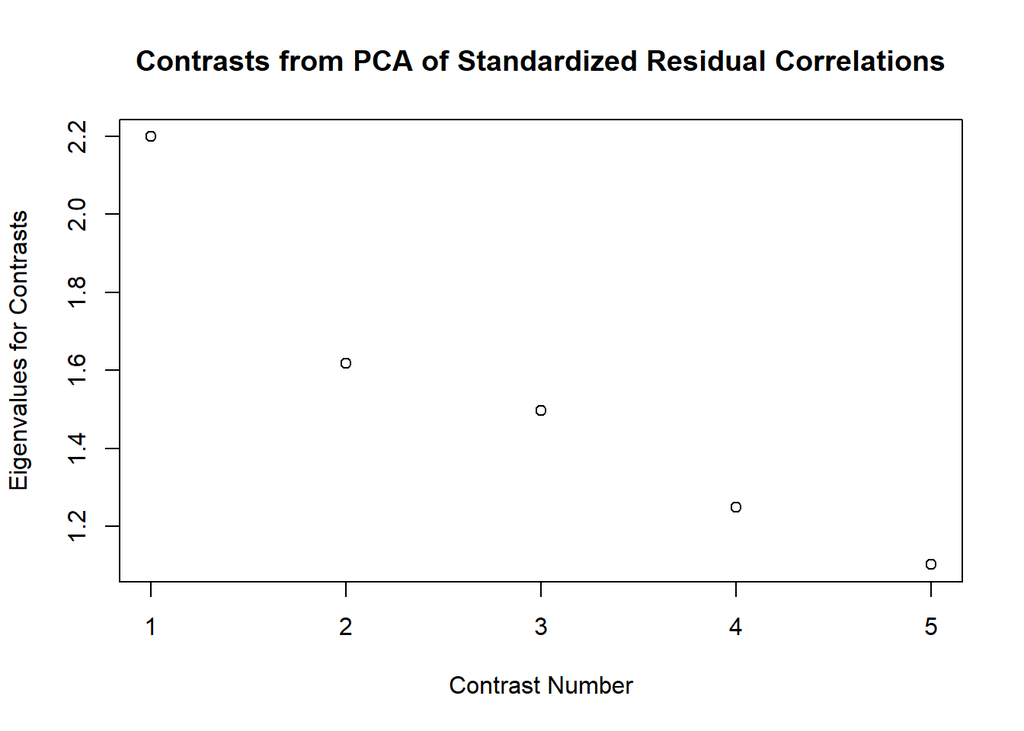

```r
#calculate std residuals of person parameters using itemfit (this is stored in 'ifit', calculated above)
#extract std residuals
std.resids <- ifit$st.res
pca <- pca(std.resids, nfactors = ncol(items), rotate = "none")
contrasts <- pca$values[1:5]
plot(contrasts, ylab = "Eigenvalues for Contrasts", xlab = "Contrast Number", main = "Contrasts from PCA of Standardized Residual Correlations")
```

We observe that the first component exceeds the threshold of 2, possibly indicating *multidimensionality*.

#### *Martin-Loef Likelihood Ratio Test*

We follow up the previous analysis with the ML test for unidimensionality.

```r
#ML using median-split criterion.
ML<- NPtest (rmat, method = "MLoef", seed= 123)
print(ML)
```

```
##
## Martin-Loef-Test (split criterion: median)
## LR-value: 16.305
## Chi-square df: 29
## p-value: 0.972
## 'exact' p-value = 0.95  (based on 500 sampled matrices)
```

The analysis yields a non significant exact p-value strongly indicating unidimensionality among items.

#### *Tmd Test*

```r
Tmd<-NPtest (rmat, method = "MLoef", seed= 123)
print(Tmd)
```

```
##
## Martin-Loef-Test (split criterion: median)
## LR-value: 16.305
## Chi-square df: 29
## p-value: 0.972
## 'exact' p-value = 0.95  (based on 500 sampled matrices)
```

### **Tests for local (in)dependence**

#### *Test for local dependence (T1)*

This method checks for local dependence via increased inter-item correlations by considering all possible item pairs and counting cases with equal responses to both items.

```r
t1<- NPtest(rmat, n=500, method ="T1", seed=123)
print(t1, alpha = 0.01)
```

```
## Nonparametric RM model test: T1 (local dependence - increased
##     inter-item correlations)
##     (counting cases with equal responses on both items)
## Number of sampled matrices: 500
## Number of Item-Pairs tested: 55
## Item-Pairs with one-sided p < 0.01
## (4,5)
##     0
```

Using 500 bootstrap samples, the analysis revealed that items 4 and 5 showed significant local dependence (p<0.01)

#### *Test for local stochastic independence (T11)*

This method calculates the sum of absolute deviations between the observed inter-item correlations and the expected correlations.

```r
t11<- NPtest(rmat, n=500, method ="T11", seed=123)
print(t11, alpha = 0.01)
```

```
## Nonparametric RM model test: T11 (global test - local dependence)
## (sum of deviations between observed and expected inter-item
##     correlations)
## Number of sampled matrices: 500
## one-sided p-value: 0.606
```

The non significant p-value indicates that the independence assumption is met.

### **Differential item functioning (DIF)/Subgroup homogeneity**

Differential Item Functioning (DIF) occurs when an item on a test behaves differently for different groups of respondents who have the same underlying ability level. In other words, a test item shows DIF if individuals from different subgroups (e.g., gender or age) have different probabilities of answering the item “correctly”, even though they have the same overall ability according to the construct being measured.

First we create two factors for gender in order to split the sample in males and females.

```r
#create two factors for gender
data.1 <- data[-pp[["pers.ex"]],]
gender<- as.factor(data.1$Sex)
levels(gender) <- c("male","female")
```

#### *Ponocny’s test for subgroup invariance (T10)*

Non-parametric global test for subgroup invariance. Checks for different item difficulties in two subgroups.

##### Median as split criterion

First we check for different item difficutlties dividing the sample in high and low performers on the latent variable.

```r
t10<- NPtest(rmat, n=500, method ="T10", splitcr="median", seed=123)
print(t10, alpha= 0.01)
```

```
## Nonparametric RM model test: T10 (global test - subgroup-invariance)
## Number of sampled matrices: 500
## Split: median
## Group 1: n =  21   Group 2: n = 23
## one-sided p-value: 0.36
```

##### Gender as split criterion

Then, we check for different items difficulties in males and females.

```r
t10.1<- NPtest(rmat, n=500, method ="T10", splitcr=gender, seed=123)
print(t10.1, alpha= 0.01)
```

```
## Nonparametric RM model test: T10 (global test - subgroup-invariance)
## Number of sampled matrices: 500
## Split: gender
## Group 1: n =  16   Group 2: n = 28
## one-sided p-value: 0.078
```

No evidence of subgroup invariance for both split criteria.

#### *Andersen’s Likelihood Ratio test*

Check for parameter invariance (item difficulty) across different subgroups. A significant LR test indicates the model does *not* fit equally well for all subgroups.

##### Median split

```r
lr <- LRtest (RaschModel, splitcr = "median")
print(lr)
```

```
##
## Andersen LR-test:
## LR-value: 11.26
## Chi-square df: 10
## p-value:  0.338
```

##### Gender split

```r
gender.1<- as.factor(data$Sex)
levels(gender.1) <- c("male", "female")
lr.1 <- LRtest (RaschModel, splitcr = gender.1, se=T)
print(lr.1)
```

```
##
## Andersen LR-test:
## LR-value: 17.489
## Chi-square df: 10
## p-value:  0.064
```

The non-significant p-values indicate that the model fits equally well for all subgroups.

#### **DIF plot**

Visual method to individuate items that perform differently for each subgroup. Each item’s ellipse should intersect the diagonal.

##### Plot split by median

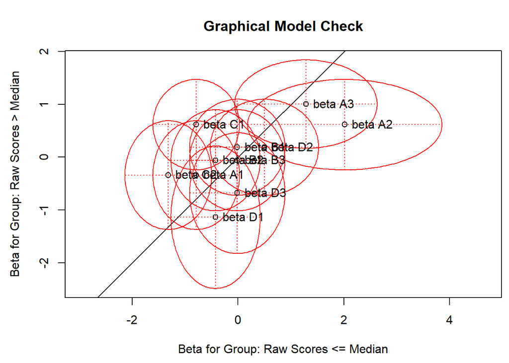

```r
lr <- LRtest (RaschModel, se=T)
difplot <-plotGOF(lr, conf = list())
```

Item C1 seems to not touch the diagonal.

##### Plot split by gender

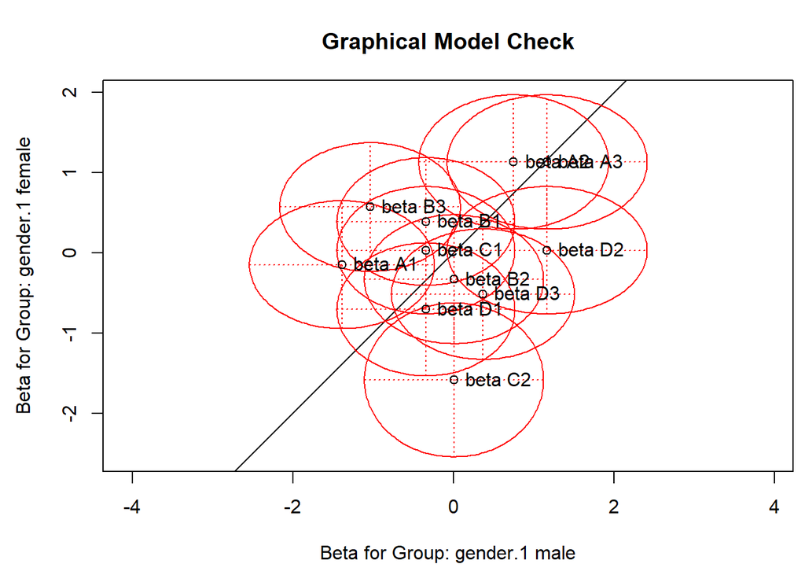

```r
difplot <-plotGOF(lr.1, conf = list())
```

Item B3 seems to be more difficult for females than for males, while the opposite seems true for item C2.

#### *Wald’s test for single items*

To quantify the conclusions drawn from the plots for single items.

##### Wald test using median split

```r
wt <- Waldtest(RaschModel, splitcr="median")
print(wt)
```

```
##
## Wald test on item level (z-values):
##
##         z-statistic p-value
## beta A1       0.676   0.499
## beta A2      -1.355   0.175
## beta A3      -0.343   0.732
## beta B1       0.308   0.758
## beta B2       0.564   0.573
## beta B3      -0.066   0.948
## beta C1       2.331   0.020
## beta C2       1.459   0.145
## beta D1      -0.875   0.382
## beta D2      -0.444   0.657
## beta D3      -0.897   0.370
```

As suggested by the graphical representation, item C1 is significant (p=0.02) on the Wald test, indicating that it behaves differently for participants with lower raw scores compared to those with higher scores. This suggests differential item functioning (DIF), meaning that the item may discriminate participants’ abilities differently across these subgroups, potentially impacting the fairness and validity of the test for certain participants. To understand whether the DIF of this item is negligible we compare item difficulty in the two subgroups.

```r
print(wt$betapar1[7]*(-1) - wt$betapar2[7]*(-1))
```

```
##   beta C1
## -1.410006
```

The comparison results in a large logit difference.

##### Wald test using gender split

```r
wt.1 <- Waldtest(RaschModel, splitcr=gender.1)
print(wt.1)
```

```
##
## Wald test on item level (z-values):
##
##         z-statistic p-value
## beta A1       1.739   0.082
## beta A2       0.515   0.607
## beta A3      -0.046   0.963
## beta B1       1.054   0.292
## beta B2      -0.479   0.632
## beta B3       2.281   0.023
## beta C1       0.541   0.589
## beta C2      -2.118   0.034
## beta D1      -0.512   0.608
## beta D2      -1.505   0.132
## beta D3      -1.235   0.217
```

Similarly, items B3 and C2 are also significant, indicating that males and females are not responding to the items in the same way.

```r
print(wt.1$betapar1[6]*(-1) - wt.1$betapar2[6]*(-1))
```

```
##   beta B3
## -1.609029
```

```r
print(wt.1$betapar1[8]*(-1) - wt.1$betapar2[8]*(-1))
```

```
##  beta C2
## 1.591129
```

The logit differences in item difficulties is consistent for the two subgroups.

### **Model Reliability**

Reliability is expressed as the quotient of true variance over observed variance and shows the level of reproducibility of the measures. The method used for estimating the true variance will produce different reliability indexes.

#### *KR-20*

This test (Kuder and Richardson 1937) is a special case of Cronbach’s alpha for dichotomous responses and based on raw score data.

```r
#Find KR-20 using the alpha function of psych, if the matrix is dichotomous it returns the KR-20 value
kr20<-alpha(rmat)
round(kr20$total$raw_al,2)
```

```
## [1] 0.74
```

The KR-20 value of 0.74 indicates a good level of internal consistency. Therefore, the scale can be considered to reliably estimate the latent variable across participants.

#### *Person separation reliability*

Similar to KR-20 but based on variance of peoples’ abilities

```r
pers_rel <- round(SepRel(pp)$sep.rel,2)
print(pers_rel)
```

```
## [1] 0.69
```

The person separation reliability of 0.69 indicates moderate reliability, meaning that the scale can distinguish between at least two levels of general ability on the latent scale, while further refinement of items and additional items may be needed to improve measurement precision.

#### *Item separation reliability*

Based on the variance of item difficulties

```r
#We obtained Betas and Standard errors before
#Then we can calculate Item separation reliability
item_rel <- round( (var(item_diff, na.rm=T) - sum((item_se)^2, na.rm=T) / sum(!is.na(item_se)))/var(item_diff, na.rm=T) ,2)
print(item_rel)
```

```
## [1] 0.72
```

Similarly, the item separation reliability 0f 0.72 indicates a moderate reliability. This means that the test can differentiate items across a reasonable difficulty range but may not cover the entire spectrum of difficulty.

#### *Item Characteristic Curves*

Item characteristic curves represent the probability of engaging in a certain behavior as a function of the position of individuals on the estimated latent trait.

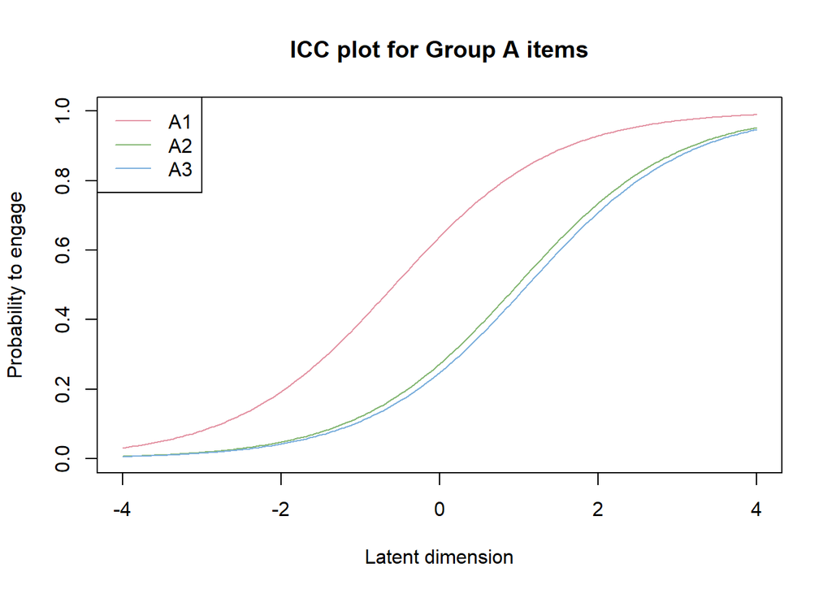

```r
joint_ICC.1<-plotjointICC(RaschModel,item.subset = 1:3, xlab = "Latent dimension", ylab="Probability to engage", legend=TRUE, legpos= "topleft", main= "ICC plot for Group A items")
```

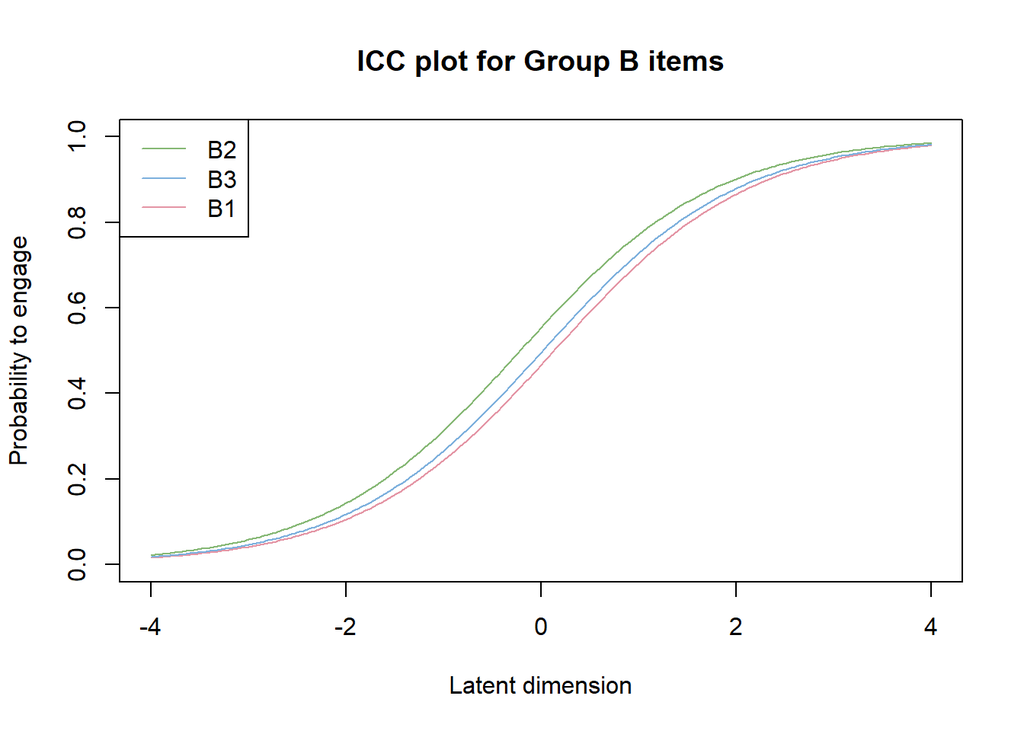

```r
joint_ICC.2<-plotjointICC(RaschModel,item.subset = 4:6, xlab = "Latent dimension", ylab="Probability to engage", legend=TRUE, legpos= "topleft", main= "ICC plot for Group B items")
```

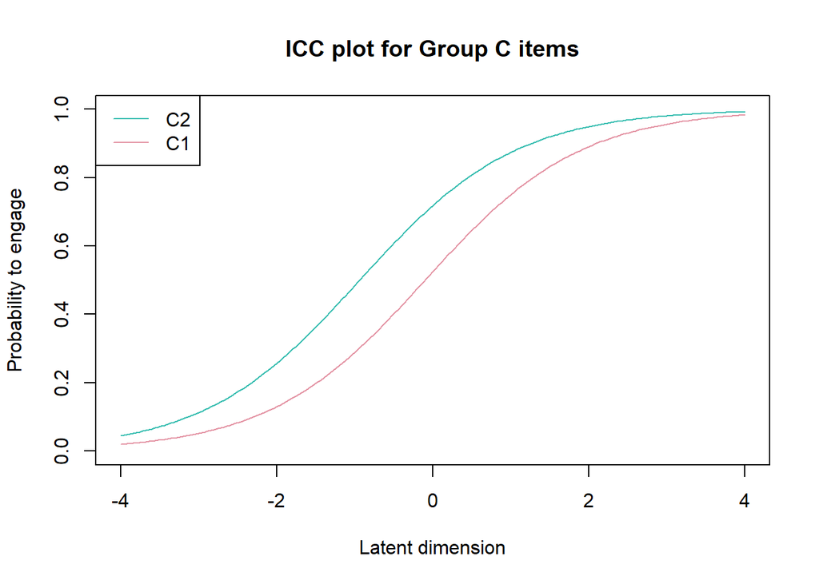

```r
joint_ICC.3<-plotjointICC(RaschModel,item.subset = 7:8, xlab = "Latent dimension", ylab="Probability to engage", legend=TRUE, legpos= "topleft", main= "ICC plot for Group C items")
```

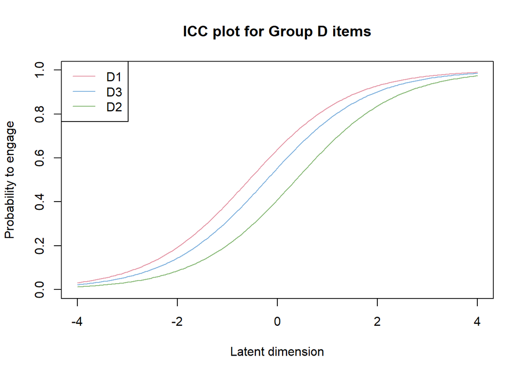

```r
joint_ICC.4<-plotjointICC(RaschModel,item.subset = 9:11, xlab = "Latent dimension", ylab="Probability to engage", legend=TRUE, legpos= "topleft", main= "ICC plot for Group D items")
```

#### *Person-Item map*

Person-item maps are useful to compare the range and position of the item measure distribution in ascending order of difficulty (lower panel) to the range and position of the person measure distribution (upper panel). Items should ideally be located along the whole scale to meaningfully measure the ‘ability’ of all persons (Bond and Fox, 2007)

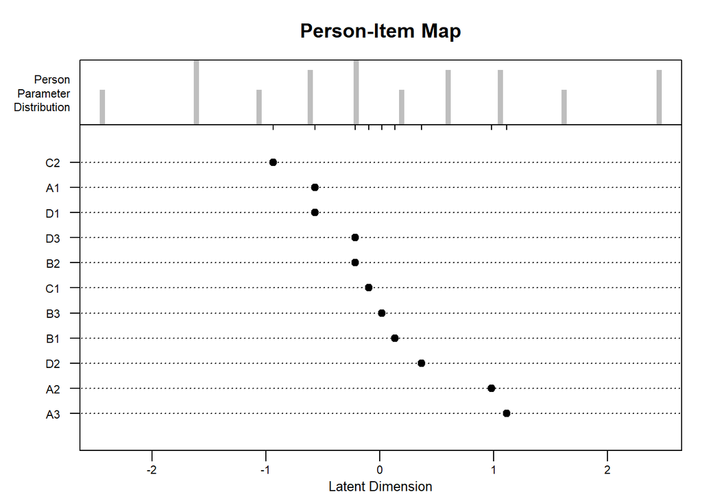

```r
pi_map<- plotPImap(RaschModel, main= "Person-Item Map", pplabel ="Person\nParameter\nDistribution",warn.ord=T,sorted = T)
```

Overall, the items are well distributed on the latent dimension without significant gaps and targeting all individuals. Two couples of items seem to be overlapping indicating that they share item difficulty. However, items do not cover all the logit range, thus items are not tailored to estimate participants with lower and higher caring attitude levels.

To better quantify the gaps in item difficulties:

```r
#Obtain item difficulty by inverting betapar (representing easiness) and order from easiest to most difficult
RaschModel$betapar[order(RaschModel$betapar*(-1))]
```

```
##     beta C2     beta A1     beta D1     beta D3     beta B2     beta C1
##  0.93730800  0.56981013  0.56980945  0.21643017  0.21643016  0.10000983
##     beta B3     beta B1     beta D2     beta A2     beta A3
## -0.01627786 -0.13275158 -0.36753515 -0.98138369 -1.11184947
```

#### *Person estimates distribution*

This graph shows the histogram of person parameter (theta) representing the distribution of the estimated caring attitude latent trait.

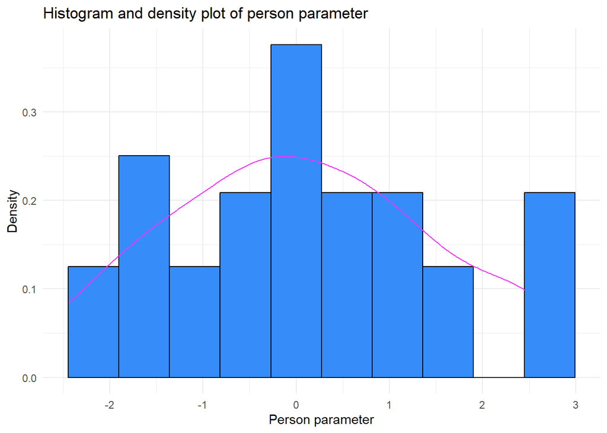

```r
library(ggplot2)
#extract caring estimate keeping only persons used for model estimation (exclude zero and perfect responses)
caring.est<- pp$theta.table$`Person Parameter`[pp$theta.table$Interpolated == FALSE]
hist_plot<- ggplot(pp$theta.table[pp$theta.table$Interpolated == FALSE,], aes(x= caring.est)) +
  geom_histogram(aes(y = ..density..),
                 colour = 1, fill = "#368CF9", bins = 10) +
  geom_density(colour= "#F636F9")+
  labs(title= "Histogram and density plot of person parameter",
       x= "Person parameter",
       y= "Density") +
  theme_minimal()
print(hist_plot)
```

##### *Normality check*

After visually inspecting the distribution we want to assess whether it is normally distributed. Indeed, the distribution of the observed latent trait in the sample is assumed to follow a Gaussian distribution. Deviations from the normal distribution would indicate that estimates are biased.

```r
#Mean and SD of difficulty estimates
M <- round(mean(caring.est),2)
print(paste("Mean=",M))
```

```
## [1] "Mean= 0.03"
```

```r
SD<- round(sd(caring.est),2)
print(paste("SD=",SD))
```

```
## [1] "SD= 1.4"
```

```r
#Shapiro-Wilk normality test
shapiro_test_result <- shapiro.test(caring.est)
print(shapiro_test_result)
```

```
##
##  Shapiro-Wilk normality test
##
## data:  caring.est
## W = 0.95802, p-value = 0.1097
```

Overall the estimated Theta distribution of the sample fits a normal distribution of Mean= 0.03 and SD= 1.4.

### **Concurrent validity**

We can now test how the estimated level of caring relates to other variables, measured with other scales. For example, we can compare caring attitude with different aspects of the arts interest scale; namely, art experience, art activities and art recognition. While we can expect an overall positive relationship between caring attitude and all dimensions of art interests I hypothesize art experience and art activities to show a stronger relationship with caring attitude compared to art recognition. We test this by running both correlation and multiple regression analyses.

```r
#Create a matrix containing the CH estimate and the other scales we want to correlate
#This time we include the CH estimate for all people, including poor scorers and perfect scorers.
caring.est<- pp$theta.table$`Person Parameter`
merged_matrix<- as.matrix(data.frame(caring.est,data$Avg_Art_Exp,data$Avg_Art_Act,data$Avg_Art_Recog))
#View correlation matrix
library(Hmisc)
# Compute the correlation matrix along with p-values and the number of observations
correlation_results <- rcorr(as.matrix(merged_matrix), type = 'pearson')
print(correlation_results)
```

```
##                    caring.est data.Avg_Art_Exp data.Avg_Art_Act
## caring.est               1.00             0.61             0.50
## data.Avg_Art_Exp         0.61             1.00             0.58
## data.Avg_Art_Act         0.50             0.58             1.00
## data.Avg_Art_Recog       0.53             0.51             0.50
##                    data.Avg_Art_Recog
## caring.est                       0.53
## data.Avg_Art_Exp                 0.51
## data.Avg_Art_Act                 0.50
## data.Avg_Art_Recog               1.00
##
## n= 52
##
##
## P
##                    caring.est data.Avg_Art_Exp data.Avg_Art_Act
## caring.est                    0e+00            1e-04
## data.Avg_Art_Exp   0e+00                       0e+00
## data.Avg_Art_Act   1e-04      0e+00
## data.Avg_Art_Recog 0e+00      1e-04            1e-04
##                    data.Avg_Art_Recog
## caring.est         0e+00
## data.Avg_Art_Exp   1e-04
## data.Avg_Art_Act   1e-04
## data.Avg_Art_Recog
```

All three dimensions of the artistic interest dimensions show moderate significant positive correlations with the Caring ability.

We can now test the extent to which the different artistic experience dimensions linearly predict caring attitude using a multiple regression model.

```r
# Fit a multiple linear regression model
multiple_model <- lm(caring.est ~ data$Avg_Art_Exp + data$Avg_Art_Act + data$Avg_Art_Recog)

# View the summary of the model to understand the contribution of each predictor
print(summary(multiple_model))
```

```
##
## Call:
## lm(formula = caring.est ~ data$Avg_Art_Exp + data$Avg_Art_Act +
##     data$Avg_Art_Recog)
##
## Residuals:
##     Min      1Q  Median      3Q     Max
## -3.1876 -0.8616  0.0964  0.6836  3.3287
##
## Coefficients:
##                    Estimate Std. Error t value Pr(>|t|)
## (Intercept)        -2.40496    0.55116  -4.363 6.77e-05 ***
## data$Avg_Art_Exp    3.44689    1.22053   2.824  0.00688 **
## data$Avg_Art_Act    0.28003    0.25952   1.079  0.28596
## data$Avg_Art_Recog  0.14043    0.07043   1.994  0.05188 .
## ---
## Signif. codes:  0 '***' 0.001 '**' 0.01 '*' 0.05 '.' 0.1 ' ' 1
##
## Residual standard error: 1.409 on 48 degrees of freedom
## Multiple R-squared:  0.4489, Adjusted R-squared:  0.4144
## F-statistic: 13.03 on 3 and 48 DF,  p-value: 2.375e-06
```

Notably, art experience is the only significant predictor of caring attitude. Interestingly, the art activities measure does not linearly predict caring attitude. As expected, art recognition does not linearly predict caring attitude. Overall, the model explains 44.89% of the variance (moderate).

Before continuing we check whether assumptions are met.

```r
library(rempsyc)
print(nice_assumptions(multiple_model))
```

```
##                                                                   Model
## 1 caring.est ~ data$Avg_Art_Exp + data$Avg_Art_Act + data$Avg_Art_Recog
##   Normality (Shapiro-Wilk) Homoscedasticity (Breusch-Pagan)
## 1                    0.776                            0.848
##   Autocorrelation of residuals (Durbin-Watson) Diagnostic
## 1                                        0.053          0
```

All assumptions are met.

## **3. Conclusion**

The proposed 11-item Caring Attitude Scale demonstrates good reliability, with a KR-20 value of 0.74 and moderate person (0.69) and item (0.72) separation reliabilities, suggesting that items may be improved in future versions. The PCA on residuals indicates the presence of a dominant first component (eigenvalue > 2), suggesting potential multidimensionality. However, the non-significant Martin-Löf test provides strong evidence of unidimensionality across the items.

While items B1 and B2 exhibit significant local dependence, the overall item set maintains local stochastic independence. Furthermore, item difficulties do not vary significantly between subgroups, as shown by both Ponocny’s and Andersen’s LR tests, when comparing responses based on a median split criterion or by gender. Despite this, some items show evidence of differential item functioning (DIF), suggesting that individual differences and gender may influence individual tendencies towards cultural heritage caring.

Notably, all the items asking about how much time and money people devote to cultural heritage caring were excluded given their elevated difficulty which was reflected in poor fit statistics. Specifically, this could be due to the age range of the sample, mainly composed of very young adults, for which asking about their dedication to CH based on money investment appears to be inappropriate.

The scale shows moderate correlations with the three artistic dimensions—art experience, art activity, and art recognition indicating a relationship between caring and these factors. However, among these, only art experience emerges as a significant predictor of caring. This finding is consistent with the theoretical framework of the scale, as art experience (i.e., personal involvement and engagement with art) is more likely to reflect an individual’s caring attitude toward cultural heritage. While art recognition may correlate with caring, it theoretically has little direct impact on caring attitudes, reinforcing the idea that the scale is capturing the most relevant aspects. Overall, the results provide evidence for the concurrent validity of the caring scale, with the strongest support coming from its relationship with art experience